# Devoir A2022

Marsel Bakashov

08 Dec 2022

```r
library(dplyr)
library(knitr)
library(ggplot2)
library(gtsummary)

opts_chunk$set(
  fig.width = 6,
  fig.height = 4,
  fig.align = 'center'
)

reset_gtsummary_theme()
```

```r
# Fonction pour calculer le coefficient de variation.
cv <- function(x) {
  return(sd(x) / mean(x))
}

# Fonction pour calculer l'écart interquartile.
iqr <- function(x) {
  return(quantile(x, .75) - quantile(x, .25))
}

# Fonction pour calculer l'erreur type
se <- function(x) {
  return(sd(x)/sqrt(length(x)))
}
```

```r
source('charger.R')
mondata<-charger(2147174)
mondata
```

|  | mpg | displacement | weight | origin |
| --- | --- | --- | --- | --- |
| 22 | 15.0 | 390.0 | 3850 | 1 |
| 81 | 23.0 | 120.0 | 2506 | 0 |
| 77 | 32.8 | 78.0 | 1985 | 0 |
| 96 | 34.4 | 98.0 | 2045 | 1 |
| 56 | 10.0 | 307.0 | 4376 | 1 |
| 208 | 11.0 | 400.0 | 4997 | 1 |
| 138 | 20.0 | 114.0 | 2582 | 0 |
| 40 | 28.0 | 97.0 | 2288 | 0 |
| 154 | 16.0 | 250.0 | 3278 | 1 |
| 60 | 13.0 | 302.0 | 3870 | 1 |

[output cut: 210 more lines]

#Phase 1 : Analyse statistique descriptive et inference

1. (2 points) Examinez les liens entre les variables quantitatives de l’étude. Pour cela, produisez une matrice des corrélations pour l’ensemble des trois variables quantitatives et commentez brièvement

```r
mcor <- cor(mondata[,1:3])
round(mcor,2)
```

```
               mpg displacement weight
mpg           1.00        -0.79  -0.82
displacement -0.79         1.00   0.93
weight       -0.82         0.93   1.00
```

2. (8 points) Pour chacune des trois variables Y (l’efficacité en carburant), X1 (la cylindrée) et X2 (le poids), produisez les graphiques et les tableaux demandés ci-dessous et interprétez brièvement les résultats dans chaque cas : • un histogramme et un diagramme de Tukey (ou «Box Plot») ;

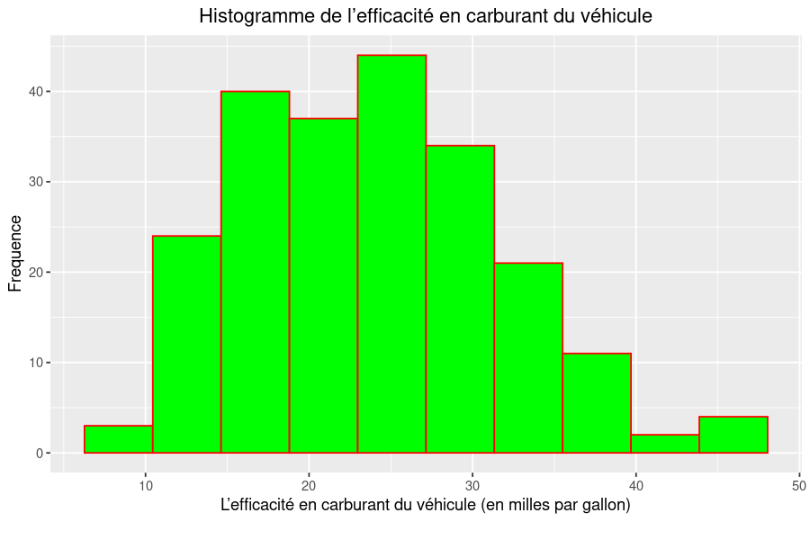

```r
mondata%>%
  ggplot(aes(x=mpg)) +
  geom_histogram(
    col = "red",
    fill = "green",
    bins = 10
  ) +
  labs(x='L’efficacité en carburant du véhicule (en milles par gallon)
', y ='Frequence') +
  ggtitle('Histogramme de l’efficacité en carburant du véhicule') +
  theme(plot.title = element_text(hjust = 0.5))
```

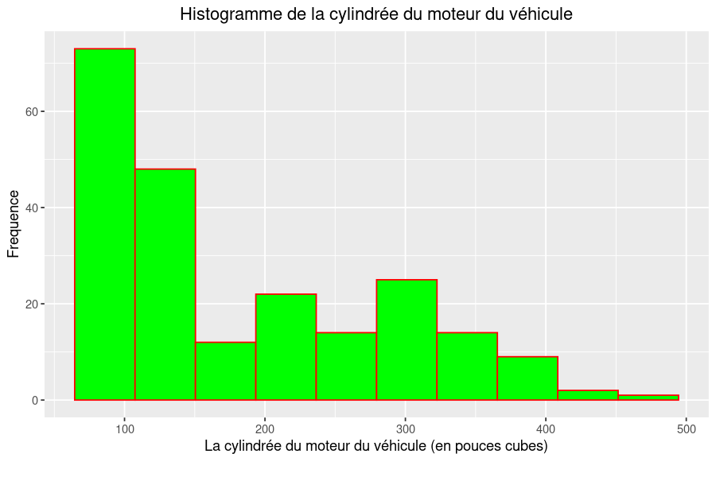

```r
mondata%>%
  ggplot(aes(x=displacement)) +
  geom_histogram(
    col = "red",
    fill = "green",
    bins = 10
  ) +
  labs(x='La cylindrée du moteur du véhicule (en pouces cubes)
', y ='Frequence') +
  ggtitle('Histogramme de la cylindrée du moteur du véhicule') +
  theme(plot.title = element_text(hjust = 0.5))
```

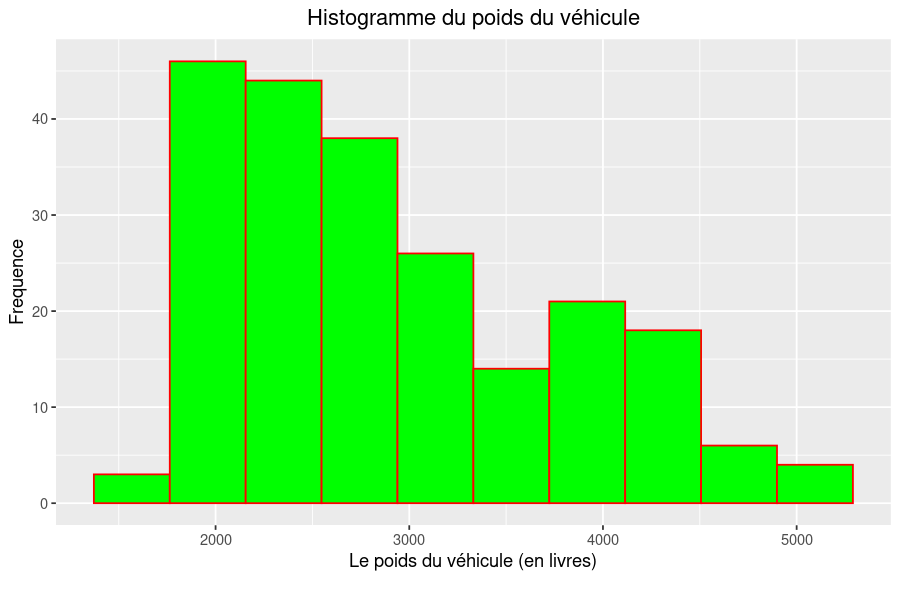

```r
mondata%>%
  ggplot(aes(x=weight)) +
  geom_histogram(
    col = "red",
    fill = "green",
    bins = 10
  ) +
  labs(x='Le poids du véhicule (en livres)
', y ='Frequence') +
  ggtitle('Histogramme du poids du véhicule') +
  theme(plot.title = element_text(hjust = 0.5))
```

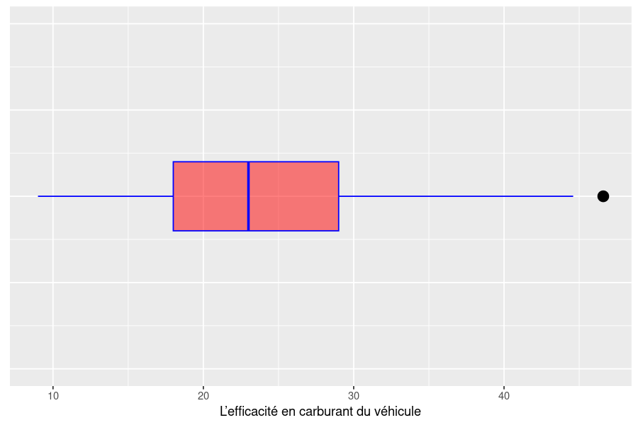

```r
mondata%>%
  ggplot(aes(x=mpg)) +
  geom_boxplot(
    color = 'blue',
    fill = 'red',
    alpha = 0.5,
    width = 0.2,
    outlier.color = 'black',
    outlier.fill = 'black',
    outlier.alpha = 1,
    outlier.size = 4
  ) +
ylim(-0.5, 0.5) +
labs(x='L’efficacité en carburant du véhicule') +
theme(
  axis.ticks.y = element_blank(),
  axis.text.y = element_blank()
)
```

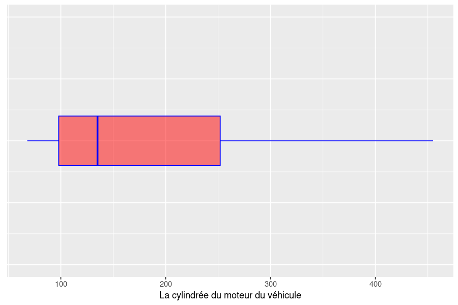

```r
mondata%>%
  ggplot(aes(x=displacement)) +
  geom_boxplot(
    color = 'blue',
    fill = 'red',
    alpha = 0.5,
    width = 0.2,
    outlier.color = 'black',
    outlier.fill = 'black',
    outlier.alpha = 1,
    outlier.size = 4
  ) +
ylim(-0.5, 0.5) +
labs(x='La cylindrée du moteur du véhicule') +
theme(
  axis.ticks.y = element_blank(),
  axis.text.y = element_blank()
)
```

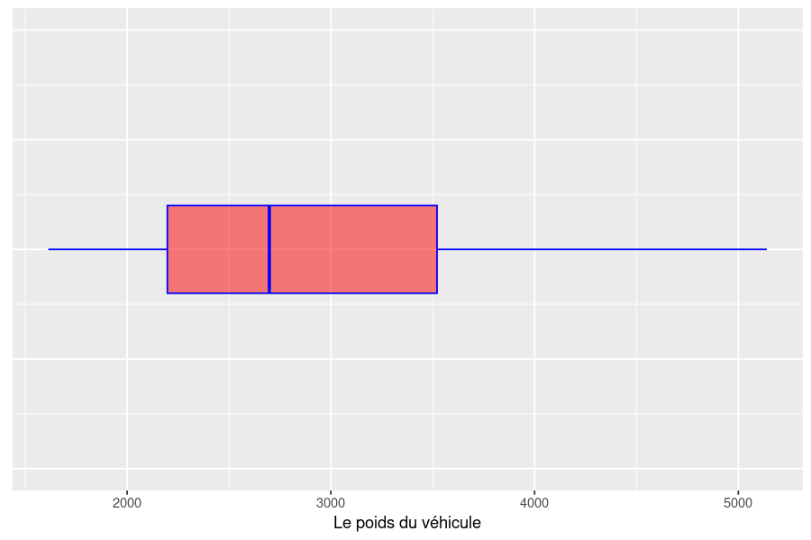

```r
mondata%>%
  ggplot(aes(x=weight)) +
  geom_boxplot(
    color = 'blue',
    fill = 'red',
    alpha = 0.5,
    width = 0.2,
    outlier.color = 'black',
    outlier.fill = 'black',
    outlier.alpha = 1,
    outlier.size = 4
  ) +
ylim(-0.5, 0.5) +
labs(x='Le poids du véhicule') +
theme(
  axis.ticks.y = element_blank(),
  axis.text.y = element_blank()
)
```

• une droite de Henry (ou «Normal Probability Plot») et un test de normalité (Shapiro-Wilk) ;

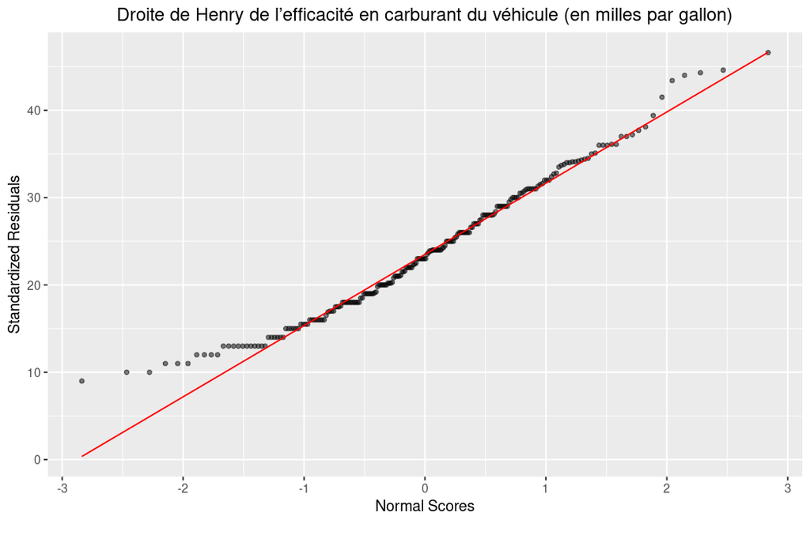

```r
mondata%>%
  ggplot(aes(sample=mpg)) +
  stat_qq(
    alpha = 0.5,
    size = 1.2
  ) +
  stat_qq_line(
    color = 'red'
  )+
  labs(x='Normal Scores
', y ='Standardized Residuals') +
  ggtitle('Droite de Henry de l’efficacité en carburant du véhicule (en milles par gallon)') +
  theme(plot.title = element_text(hjust = 0.5))
```

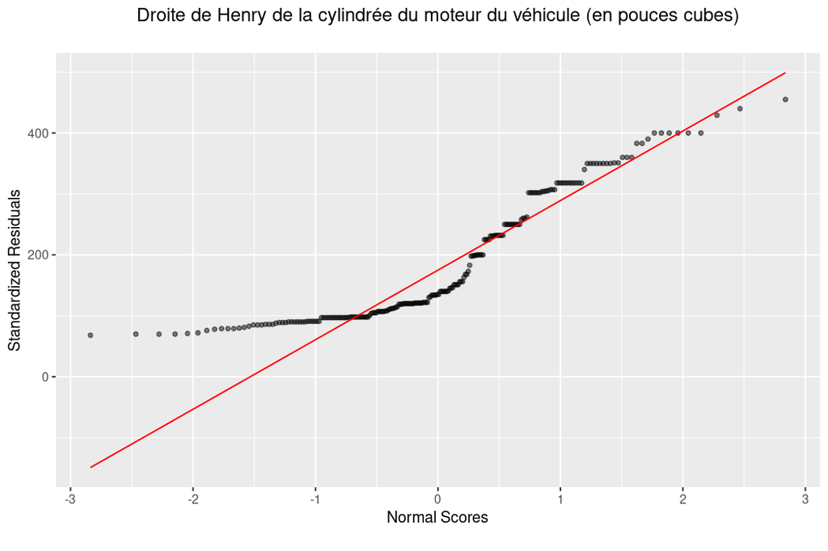

```r
mondata%>%
  ggplot(aes(sample=displacement)) +
  stat_qq(
    alpha = 0.5,
    size = 1.2
  ) +
  stat_qq_line(
    color = 'red'
  )+
  labs(x='Normal Scores
', y ='Standardized Residuals') +
  ggtitle('Droite de Henry de la cylindrée du moteur du véhicule (en pouces cubes)
') +
  theme(plot.title = element_text(hjust = 0.5))
```